# JielinYu_Junior_Data_Analyst

## Import Packages

```python
import pandas as pd
import numpy as np
import time
from urllib.request import urlopen
import requests
import re
import time
import warnings
warnings.filterwarnings("ignore")

# Web Scraping
from bs4 import BeautifulSoup
import spacy

#nltk
import nltk
from nltk import bigrams, trigrams
from nltk import ngrams
from nltk.tokenize import word_tokenize

# Visualization
from wordcloud import WordCloud
import matplotlib.pyplot as plt
%matplotlib inline

# sklearn
from sklearn.feature_extraction.text import TfidfVectorizer
from sklearn.cluster import KMeans
from sklearn import cluster
from sklearn import metrics
from collections import Counter
from sklearn.cluster import DBSCAN
```

### Web Scraping 200 Data Scientist Jobs from Indeed

```python
def web_scrape(search_position, search_location, output_path):
    """
    Given desired position, location, and output file path, save the job posting information as a csv file.

    Keyword arguments:
    search_position -- (str) the job position
    search_location -- (str) the job location
    output_path -- (str) the output file path
    """
    job_list = []
    title = []
    location = []
    company = []
    description = []
    url_http = "https://www.indeed.ca/m/"
    # Scrape 200 jobs
    for i in range(20):
        time.sleep(1)
        jobs_html = requests.get("https://www.indeed.ca/m/"+"jobs?q="\
                                 +search_position+"&l="+search_location+"&start="+str(i*10))
        job_bs = BeautifulSoup(jobs_html.text)
        for link in job_bs.find_all('a',{'rel':"nofollow"}):
            job_list.append(url_http + link.get('href'))
    # Scrape jobs' information
    for job in job_list:
        job_50 = requests.get(job)
        bs_50 = BeautifulSoup(job_50.text)
        title.append(bs_50.find('font',{'size':'+1'}).text)
        location.append(bs_50.find('span',{'class':'location'}).text)
        company.append(bs_50.find('span', {'class':"location"}).previous_sibling)
        description.append(bs_50.find('div',{'id':'desc'}).text)
    # Make a dataframe
    table = pd.DataFrame({'Company':company,
              'Location':location,
              'Title':title,
              'Description':description,
              'Link':job_list})
    # Save csv
    table.to_csv(output_path)
```

```python
search_position = "data+scientist"
search_location = "Canada"
output_path = "Data_Scientist_Jobs.csv"
web_scrape(search_position, search_location, output_path)
```

```python
table = pd.read_csv('Data_Scientist_Jobs.csv', index_col=0)
```

[output not shown]

### Clean and Preprocess Job Description

```python
nlp = spacy.load("en")

def preprocess(text,
               irrelevant_pos = ['ADV','PRON','CCONJ','PUNCT','PART','DET','ADP','SPACE','VERB']):
    """
    Given text, and irrelevant_pos carry out preprocessing of the text
    and return a preprocessed string.

    Keyword arguments:
    text -- (str) the text to be preprocessed
    irrelevant_pos -- (list) a list of irrelevant pos tags

    Returns: (str) the preprocessed text
    """
    # Remove distracting characters
    text = re.sub(r'\s+', ' ', text)
    text = re.sub(r'''[\*\~]+''', "", text)

    # Customized Stopwords
    # The job postings contains some French as these are jobs in Canada
    stopwords = [
    "jobs", "apply", "email", "password", "new", "please", "required",
    "opportunities", "skills", "sign", "talent", "follow",  "job", "work",
    "click", "home", "next", "us", "start", "take", "enter", "date", "people",
    "career", "hours", "week", "type", "attach", "resume", "search", "advanced",
    "privacy", "terms", "find", "years", "experience", "find", "title", "keywords",
    "company", "indeed", "help", "centre", "cookies", "post", "(free)", "industry",
    "employment", "ago", "save", "forums", "browse", "employer", "browse", "city",
    "province", "title", "api", "review", "application", "help", "instructions",
    "applying", "full", "time", "opportunity", "team", "join", "resumes", "employers",
    "rights", "reserved", "create", "north", "america", "toronto", "interview", "cover",
    "letter", "30+", "days", "inc", "trends", 'de', 'le', 'ericsson', 'dans', 'des',
    'working', 'etc.', 'canada', 'les', 'employees', 'accommodation',
    'et', 'montréal','en','mi','yoga','à','équipe','vancuover','se','se se'
    ]

    text = " ".join([i.lower() for i in text.split() if i.lower() not in stopwords])

    doc = nlp(text)
    clean_text = []

    for token in doc:
        if (token.is_stop == False # Check if it's not a stopword
            and token.is_alpha # Check if it's an alphanumerics char
            and token.pos_ not in irrelevant_pos): # Check if it's irrelevant pos
            clean_text.append(str(token))
    return " ".join(clean_text)
```

```python
table['clean_description'] = table['Description'].apply(preprocess)
```

## Method 1: Most 20 Common n-gram words

```python
# Show frequency of contiguous sequence of 1,2,3 items respectively
sent_list = [i.split() for i in table['clean_description'].tolist()]
# Unigram
unigram = [[gram for gram in ngrams(sent,1)] for sent in sent_list]
uni_20 = Counter(sum(unigram, [])).most_common(20)
# Bigrams
bigrams = [[gram for gram in ngrams(sent,2)] for sent in sent_list]
bi_20 = Counter(sum(bigrams, [])).most_common(20)
#Trigrams
trigrams = [[gram for gram in ngrams(sent,3)] for sent in sent_list]
tri_20 = Counter(sum(trigrams, [])).most_common(20)

pd.DataFrame({'Unigram':uni_20,'Bigram':bi_20,'Trigram':tri_20})
```

|  | Unigram | Bigram | Trigram |
| --- | --- | --- | --- |
| 0 | ((data,), 1897) | ((machine, learning), 216) | ((machine, learning, techniques), 35) |
| 1 | ((science,), 477) | ((data, science), 211) | ((large, data, sets), 31) |
| 2 | ((business,), 430) | ((data, scientist), 155) | ((degree, computer, science), 23) |
| 3 | ((machine,), 384) | ((computer, science), 106) | ((natural, language, processing), 18) |
| 4 | ((learning,), 339) | ((big, data), 91) | ((learning, deep, learning), 17) |
| 5 | ((research,), 319) | ((data, sets), 76) | ((data, sources, data), 16) |
| 6 | ((analysis,), 283) | ((data, mining), 74) | ((machine, learning, deep), 16) |
| 7 | ((development,), 264) | ((deep, learning), 70) | ((computer, science, engineering), 16) |
| 8 | ((knowledge,), 261) | ((artificial, intelligence), 58) | ((data, science, machine), 15) |
| 9 | ((information,), 261) | ((data, analysis), 55) | ((computer, science, statistics), 15) |
| 10 | ((models,), 248) | ((data, scientists), 50) | ((se, se, se), 15) |
| 11 | ((analytics,), 229) | ((data, sources), 48) | ((global, ai, accelerator), 14) |
| 12 | ((solutions,), 226) | ((python, r), 43) | ((data, visualization, tools), 14) |
| 13 | ((ability,), 224) | ((large, data), 40) | ((computer, science, related), 14) |
| 14 | ((environment,), 223) | ((open, source), 40) | ((large, scale, data), 14) |
| 15 | ((tools,), 211) | ((large, scale), 38) | ((public, service, skilled), 14) |
| 16 | ((python,), 211) | ((selection, process), 37) | ((service, skilled, diverse), 14) |
| 17 | ((données,), 209) | ((learning, techniques), 37) | ((skilled, diverse, workforce), 14) |
| 18 | ((techniques,), 201) | ((data, analytics), 37) | ((inclusive, barrier, free), 14) |
| 19 | ((scientist,), 197) | ((data, visualization), 35) | ((machine, learning, models), 13) |

### Visualization

Unigram does not really give us meaningful insights, let's visualize Bigram and Trigram words count.

[figure not shown]

```python
bi = [bi_20[i][0] for i in range(len(bi_20))]
height_bi = [bi_20[i][1] for i in range(len(bi_20))]
y_pos = np.arange(len(bi))
tri = [tri_20[i][0] for i in range(len(tri_20))]
height_tri = [tri_20[i][1] for i in range(len(tri_20))]
y_pos_tri = np.arange(len(tri))
# Plot Bigram
plt.figure(figsize=(12,10))
plt.subplot(2,1,1)
plt.barh(y_pos, height_bi)
plt.yticks(y_pos, bi)
plt.title("Bigram Count")
plt.gca().invert_yaxis();
# Plot Trigram
plt.subplot(2,1,2)
plt.barh(y_pos_tri, height_tri)
plt.yticks(y_pos_tri, tri)
plt.title("Trigram Count")
plt.gca().invert_yaxis();
```

From the plot above, we can see that **Machine Learning**, **Computer Science**, **Data Mining**, **Deep Learning**, **Python**, **R**, **Big Data**, and **Artificical Intelligence** are important skills for data scientist since these key words are mentioned most frequently in most of the job postings. **Machine Learning** seems is the most important skills for data scientist.

## Method 2: TF-IDF Vectorizer

The TF-IDF algorithm is used to weigh a keyword in any content and assign the importance to that keyword based on the number of times it appears in the document. More importantly, it checks how relevant the keyword is throughout the web, which is referred to as corpus.

- TF refers to term frequency of a term in a document.
- DF refers to the number of documents of the corpus in which this term occurs.

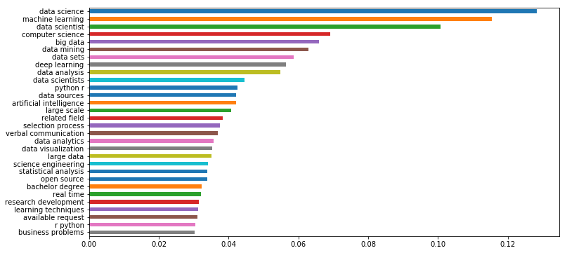

```python
vectorizer = TfidfVectorizer(use_idf=True,
                             tokenizer=nltk.word_tokenize,
                             ngram_range=(2, 5),max_features=100)
tfidf_vectors = vectorizer.fit_transform(table['clean_description'])
tfidf_post = pd.DataFrame(tfidf_vectors.toarray(),
                          columns=vectorizer.get_feature_names())
plt.figure(figsize=(12,6))
# Take average of tfidf vectors (TF/DF)
tfidf_post.mean(axis=0).sort_values(ascending=False)[:30].plot.barh()
plt.gca().invert_yaxis();
```

## Method 3: Word Cloud

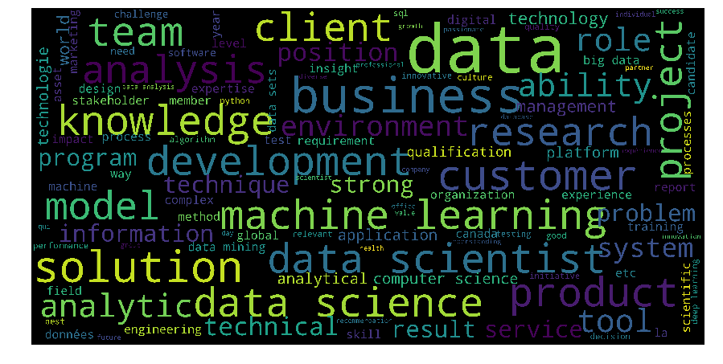

```python
wordcloud = WordCloud(background_color='black',
                      max_words=200,
                      scale=30,
                      max_font_size=40).generate(" ".join(table['clean_description']))
# print(wordcloud)
fig = plt.figure(1, figsize=(15,15))
plt.imshow(wordcloud)
plt.axis('off')
plt.show()
```

We can see that **machine learning** is a big part, which aligns with the two findings above. Again, as we can see, **big data**, **Computer Science**, and **Algorithm** are important skills as well. In terms of the types of coding languages that data scientists should use, I can see that there is **python** and **sql**. Moreover, skills of interpreting data science findings to **Business** solution to customers and **team work** are important as well.

## Clustering - Kmeans

I think **Kmeans** would be the best clustering algorithm to be used in this case. Since we do not have labelled data, I can only use unsupervised learning techniques such as Kmeans, DBScan, hierarchical clustering, and LDA model, etc. Kmeans is one of the most effective clustering algorithm for text data. Kmeans algorithm is an iterative algorithm that tries to partition the dataset into K pre-defined distinct non-overlapping subgroups (clusters) where each data point belongs to only one group. It tries to make the inter-cluster data points as similar as possible while also keeping the clusters as different (far) as possible.

To choose the number of clusters, I use **Elbow Method**. Elbow method gives us an idea on what a good k number of clusters would be based on the sum of squared distance (SSE) between data points and their assigned clusters’ centroids. We pick k at the spot where SSE starts to flatten out and forming an elbow.

```
Text(0,0.5,'SSE')
```

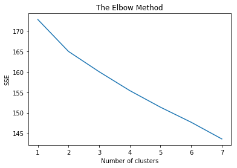

```python
wcss = []
for i in range(1,8):
    kmeans = KMeans(n_clusters=i,init='k-means++',max_iter=300,n_init=10,random_state=0)
    kmeans.fit(tfidf_vectors)
    wcss.append(kmeans.inertia_)
plt.plot(range(1,8),wcss)
plt.title('The Elbow Method')
plt.xlabel('Number of clusters')
plt.ylabel('SSE')
```

From the plot, it is not obvious when SSE forms an elbow. Therefore, let's try 2, 3, and 4 clusters.

```python
for ncluster in range(2,5):
    print("Number of Clusters:" + str(ncluster))
    words = vectorizer.get_feature_names()
    kmeans = KMeans(n_clusters = ncluster, n_init = 10, n_jobs = 1,init='k-means++',random_state=42) # n_init(number of iterations for clsutering) n_jobs(number of cpu cores to use)
    kmeans.fit(tfidf_vectors)
# We look at 3 the clusters generated by k-means.
    common_words = kmeans.cluster_centers_.argsort()[:,-1:-16:-1]
    for num, centroid in enumerate(common_words):
        print(str(num) + ' : ' + ', '.join(words[word] for word in centroid))
        print("-----------------")
    #print("----------------------------------------------------------------")
```

```
Number of Clusters:2
0 : research development, public service, selection process, available request, related field, verbal communication, following essential, data management, successful candidate, essential qualifications, canadian citizens, se se, data collection, post secondary, hiring process
-----------------
1 : data science, machine learning, data scientist, computer science, big data, data mining, data sets, deep learning, data analysis, data scientists, python r, artificial intelligence, large scale, data sources, large data
-----------------
Number of Clusters:3
0 : research development, related field, public service, available request, selection process, verbal communication, science engineering, data management, following essential, data collection, essential qualifications, canadian citizens, se se, successful candidate, computer science engineering
-----------------
1 : deep learning, machine learning, artificial intelligence, natural language, learning deep, learning deep learning, natural language processing, language processing, machine learning deep learning, machine learning deep, data scientist, data mining, computer science, machine algorithms, data scie…
-----------------
2 : data science, data scientist, machine learning, data sets, big data, computer science, data mining, data analysis, data scientists, python r, large data, data sources, open source, large data sets, data visualization
-----------------
Number of Clusters:4
0 : machine learning, data scientist, data mining, deep learning, data sets, computer science, data analysis, big data, data sources, large data, r python, data insights, statistical analysis, artificial intelligence, large data sets
-----------------
1 : data science, machine learning, data scientist, computer science, big data, data scientists, machine models, open source, python r, large scale, real time, business problems, data analysis, science engineering, data sets
-----------------
2 : research development, related field, available request, selection process, verbal communication, traitement données, data management, nous sommes, un environnement, successful candidate, data collection, large scale, data products, internal external, bachelor degree
-----------------
3 : public service, following essential, se se, essential qualifications, canadian citizens, language requirements, preference veterans, post secondary, selection process, closing date, hiring process, research development, successful candidate, science engineering, data management
-----------------
```

## 3 Clusters

```python
words = vectorizer.get_feature_names()
kmeans = KMeans(n_clusters = 3, n_init = 10, n_jobs = 1,init='k-means++',random_state=42) # n_init(number of iterations for clsutering) n_jobs(number of cpu cores to use)
kmeans.fit(tfidf_vectors)
# We look at 3 the clusters generated by k-means.
common_words = kmeans.cluster_centers_.argsort()[:,-1:-16:-1]
for num, centroid in enumerate(common_words):
    print(str(num) + ' : ' + ', '.join(words[word] for word in centroid))
    print("-----------------")
```

```
0 : research development, related field, public service, available request, selection process, verbal communication, science engineering, data management, following essential, data collection, essential qualifications, canadian citizens, se se, successful candidate, computer science engineering
-----------------
1 : deep learning, machine learning, artificial intelligence, natural language, learning deep, learning deep learning, natural language processing, language processing, machine learning deep learning, machine learning deep, data scientist, data mining, computer science, machine algorithms, data scie…
-----------------
2 : data science, data scientist, machine learning, data sets, big data, computer science, data mining, data analysis, data scientists, python r, large data, data sources, open source, large data sets, data visualization
-----------------
```

From the results above, I think clustering skill sets to 3 groups is the best way as I can see clear distinction among three groups. We can clearly see that the first critical skill set is about **soft skills**, including verbal communication, public service, research development, and canadaian citizen; the second skill set is **cutting-edge technical skills**, including machine learning, AI, NLP, deep learning and data mining; the third skill set is **techinical tools**, including R, Python, open source and large data sets.

## Synopsis

- In summary, this application can serve different groups in society to perform better in the labor market. For displaced workers or employee who are pursuing a different filed of career, they can use this analyzer to help them find in-demand online classes and learning materials to meet jobs' requirements. For example, by using the analyzer, a non-technical employee who wants to transfer his/her career to data science will know that he/she needs to acquire machine learning skills, statistical analysis, computer science and great communication skills in order to be a qualified candidate. In addition, it can also help academic institutions to improve their course design. For example, master of data science program at UBC can use it to find out how course contents they need to modify. The program has already provided machine learning, python, and data visualization classes. By using this analyzer, they may want to design more classes focusing on technical communication and big data analysis to help their students find their dream jobs. Moreover, talent acquisition partners can find the right candidates with right skills for their company easier.

## Web Scraping Challenges

- Indeed does not provide an API tool for users to analyze data, thus I need to scrape job postings page by page using Python package such as BeautifulSoup.
- When retrieving key words of job postings from the website version of Indeed, it's hard to find the pattern of each job post url because of its complex html format and there are too many irrelevant information like advertisemnts in each website. Therefore, in order to find important information from each job description easily, I extracted information using the mobile version because it gives me a much cleaner html format.